# Trillium Smith — Event Kit

## Short bio

> Trillium Smith is a software developer and open-source contributor who codes hands-free using tools like Talon Voice and Cursorless. He builds developer and AI tooling and enjoys sharing what he’s learned about alternative ways of interacting with computers — from voice accessibility on macOS, Linux, and Windows to using dictation to direct AI agents from a desktop or a phone. Outside of code, he’s a former massage therapist and salsa dance instructor.

## Presentation

Title options (pick one that would fit the audience better):

- Voice-Driven Development: Talking to Computers to Write Code
- Beyond the Keyboard: An Alternate Way of Using Computers

> In this live demo, Trillium Smith codes hands-free in front of your eyes — no keyboard, no mouse — and breaks down how voice-driven development actually works. Using Talon Voice and Cursorless, he’ll write real code live, narrate every step in plain language, and show how AI agents fit into a hands-free workflow. You’ll leave with a practical feel for accessibility-first tooling and ideas you can steal for your own setup, whether or not you ever ditch your keyboard. No prior voice-coding experience needed. Q&A included.

## What I will demo

- Voice accessibility on macOS (compatible with Linux X11 and Windows)
- Dictation as a way to direct AI agents
  - through the desktop
  - through a phone

## Photo

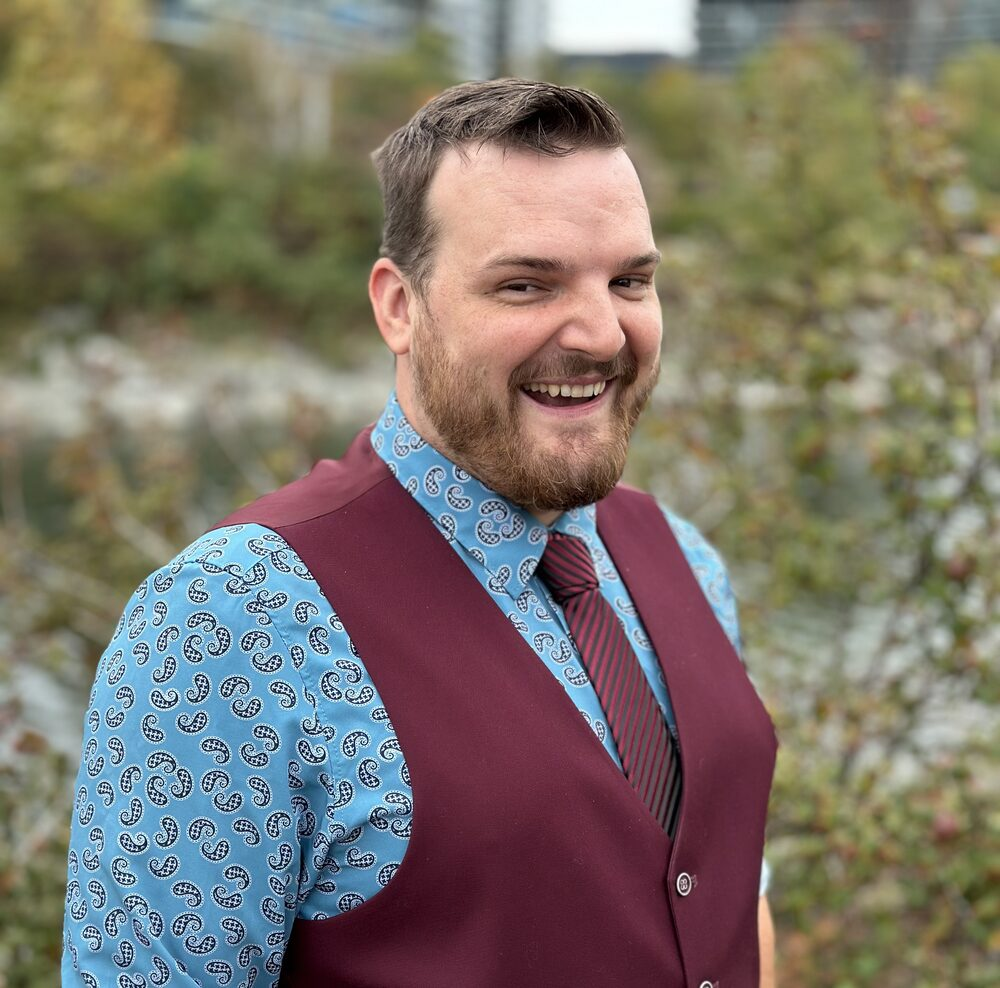

Trillium Smith headshot